# Overview of the Data Mining Process

MGS3701 Data Mining, Spring 2025

Chad (Chungil Chae)

cchae@kean.edu

Tue, 27 May 2025

# Learning Objectives

## SHORT VIDEO INTRODUCTION

[video not shown]

# Introduction

- In this chapter, we introduce the variety of methods sometimes referred to as data mining.
- Data mining focuses on what has come to be called predictive analytics, the tasks of:
  - **Classification**
  - **Prediction**
  - **Pattern Discovery**

# Core Idea in Data Mining

## Classification

- Classification is the most basic form of data analysis.
  - e.g., application of a loan, credit card transaction
- To examine data where the classification is
  - unknown or
  - will occur in the future
- Similar to classification is develop rules

## Prediction

- Prediction is to predict **the value of a numerical variable** (e.g., amount of purchase) rather than a class (e.g.,purchaser or nonpurchaser).
- the value of a continuous variable.

## Assiciation Rules and Recommendation Systems

- **What goes with what**
- Association rules, or affinity analysis, is designed to find such **general associations patterns** between items in large databases.
  - grocery stores: product placement, weekly promotional offers, bundling products.
  - hospital database: which symptom is followed by what other symptom to help predict future symptoms for returning patients.
  - Online recommendation systems: collaborative filtering

**Collaborative filtering**

Collaborative filteringa method that uses individual users’ preferences and tastes given their historic purchase, rating, browsing, or any other measurable behavior indicative of preference, as well as other users’ history.

**Association rules vs Collaborative filtering**

In contrast to association rules that generate rules general to an entire population, collaborative filtering generates “what goes with what” at the individual user level. Hence, collaborative filtering is used in many recommendation systems that aim to deliver personalized recommendations to users with a wide range of preferences.

## Predictive Analytics

- Classification, prediction, and to some extent, association rules and collaborative filtering constitute the analytical methods employed in predictive analytics.
- The term predictive analytics is sometimes used to also include data pattern identification methods such as clustering.

## Data Reduction and Dimension Reduction

- Data mining algorithms is often improved
  - when the number of variables is limited, and
  - when large numbers of records can be grouped into homogeneous groups.
- For example,
  - rather than dealing with thousands of product types, an analyst might wish to group them into a smaller number of groups and build separate models for each group.
  - Or a marketer might want to classify customers into different “personas,” and must therefore group customers into homogeneous groups to define the personas.
- This process of consolidating a large number of records (or cases) into a smaller set is termed data reduction. Methods for reducing the number of cases are often called clustering.
- Reducing the number of variables is typically called dimension reduction.
  - Dimension reduction is a common initial step before deploying data mining methods, intended to improve predictive power, manageability, and inter-pretability.

## Data Exploration and Visualization

- Exploration is aimed at
  - understanding the global landscape of the data, and
  - detecting unusual values.
- Exploration is used for **data cleaning** and **manipulation** as well as for **visual discovery** and **hypothesis generation**.
- Methods for exploring data include looking at various data aggregations and summaries
- (Both numerically and graphically) looking at each variable separately as well as looking at relationships among variables.
- The purpose is to **discover patterns** and **exceptions**.
- Data Visualization or Visual Analytics - Exploration by creating charts and dashboards
- **For numerical variables**,
  - we use histograms and boxplots to learn about the distribution of their values,
    - to detect outliers (extreme observations), and to
    - find other information that is relevant to the analysis task.
- **For categorical variables**,
  - we use bar charts. We can also look at scatter plots of pairs of numerical variables
    - to learn about possible relationships,
    - the type of relationship,
    - to detect outliers.

> Visualization can be greatly enhanced by adding features such as color and interactive navigation.

## Supervised and Unsupervised Learning

[video not shown]

### Supervised Learning Algorithms

- Supervised learning algorithms are those used in **classification** and **prediction**.
  - We must have data available in which the value of the outcome of interest (e.g., purchase or no purchase) is known, “labeled data”
  - These training data are the data from which the classification or prediction algorithm “learns,” or is “trained,” about the relationship between predictor variables and the outcome variable.
  - Once the algorithm has learned from the training data, it is then applied to **another sample of labeled data (the validation data)** where the *outcome is known but initially hidden*, to see how well it does in comparison to other models.
  - If many different models are being tried out, it is prudent to save a third sample, which also includes known outcomes (the test data) to use with the model finally selected to predict how well it will do.
  - The model can then be used to classify or predict the outcome of interest in new cases where the outcome is unknown.

**Linear Regression as Supervised Machine Learning Algorithm**

- Simple linear regression is an example of a supervised learning algorithm (although rarely called that in the introductory statistics course where you probably first encountered it).
  - The Y variable is the (known) outcome variable and the X variable is a predictor variable.
  - A regression line is drawn to minimize the sum of squared deviations between the actual Y values and the values predicted by this line.
  - The regression line can now be used to predict Y values for new values of X for which we do not know the Y value.

### Unsupervised Learning Algorithms

- Unsupervised learning algorithms are those used where there is no outcome variable to predict or classify.
- Hence, there is no “learning” from cases where such an outcome variable is known.
- Association rules, dimension reduction methods, and clustering techniques are all unsupervised learning methods.
- Supervised and unsupervised methods are sometimes used in conjunction.

**Note**

For example, unsupervised clustering methods are used to separate loan applicants into several risk-level groups. Then, supervised algorithms are applied separately to each risk-level group for predicting propensity of loan default.

# The Steps in Data Mining

## Data Mining Steps

1. **Develop an understanding of the purpose of the data mining project.**
2. **Obtain the dataset to be used in the analysis.**
3. **Explore, clean, and preprocess the data.**
4. **Reduce the data dimension, if necessary.**
5. **Determine the data mining task.**
6. **Partition the data (for supervised tasks).**
7. **Choose the data mining techniques to be used.**
8. **Use algorithms to perform the task.**
9. **Interpret the results of the algorithms.**
10. **Deploy the model.**

## SEMMA

The foregoing steps encompass the steps in SEMMA, a methodology developed by the software company SAS:

- **Sample**: Take a sample from the dataset; partition into training, validation, and test datasets.
- **Explore**: Examine the dataset statistically and graphically.
- **Modify**: Transform the variables and impute missing values.
- **Model**: Fit predictive models (e.g., regression tree, neural network).
- **Assess**: Compare models using a validation dataset.

> IBM SPSS Modeler (previously SPSS-Clementine) has a similar methodology, termed CRISP-DM (CRoss-Industry Standard Process for Data Mining). All these frameworks include the same main steps involved in predictive modeling.

## Other Models

- **[KDD Model](https://medium.com/@shawn.chumbar/kdd-process-in-data-science-a-beginners-guide-426d1f0fc062)**: Knowledge Discovery in Databases (KDD) is a systematic process that seeks to identify valid, novel, potentially useful, and ultimately understandable patterns from large amounts of data. In simpler terms, it’s about transforming raw data into valuable knowledge.
- **[CRISP-DM](https://medium.com/@shawn.chumbar/the-crisp-dm-process-a-comprehensive-guide-4d893aecb151)**: CRISP-DM stands for Cross-Industry Standard Process for Data Mining. It is a cyclical process that provides a structured approach to planning, organizing, and implementing a data mining project. The process consists of six major phases: Business Understanding, Data Understanding, Data, Preparation, Modeling, Evaluation, Deployment

[video not shown]

# Preliminary Steps

## Organization of Datasets

> In supervised learning situations, one of these variables will be the outcome variable, **TOTAL VALUE**).

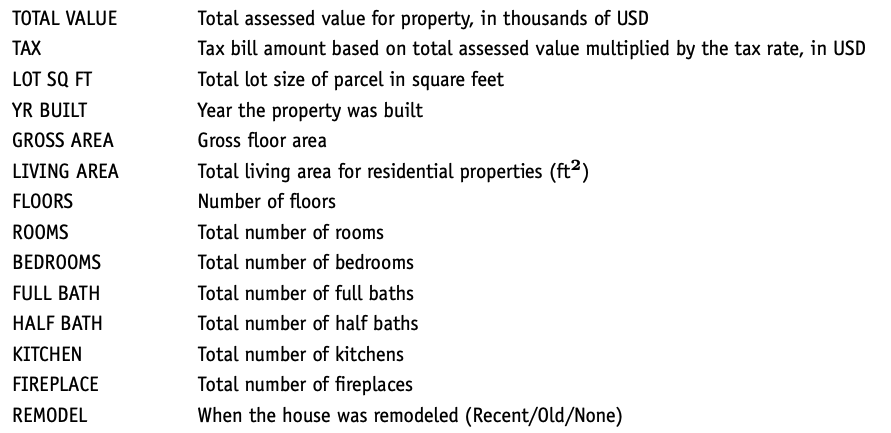

Harney, K., Zestimates may not be as right as you’d like”, Washington Post, Feb. 7, 2015, p. T10

## Loading and Looking at the Data in R

- To load data into R, we will typically want to have the data available as a CSV (comma-separated values) file. If the data are in an XLS (or XLSX) file, we can save that file in Excel as a CSV file by going to **File > Save as > Save as type: CSV (Comma delimited) (*.csv) > Save**.

**When dealing with `.csv` files in Excel, beware of two pitfalls**

- Opening a `.csv` file in Excel strips off leading zeros, which can corrupt zipcode data.
- Saving a `.csv` file in Excel saves only the digits that are displayed; if you need precision to a certain number of decimals, ensure they are displayed before saving.
- Once we have R and RStudio installed on our machine and the `WestRoxbury.csv` file saved as a CSV file, we can run the code in Table 2.3 to load the data into R.
- Data from a CSV file is stored in R as a **data frame** (e.g., `housing.df`).
- If our CSV file has column headers, these headers get automatically stored as the column names of our data.
- A data frame is the fundamental object almost all analyses begin with in R.
- A data frame has rows and columns: the rows are the observations for each case (e.g., house), and the columns are the variables of interest (e.g., `TOTAL VALUE`, `TAX`).

```
Table2.3
```

```r
housing.df <- read.csv("data/WestRoxbury.csv", header = TRUE)  # load data
dim(housing.df)  # find the dimension of data frame
head(housing.df)  # show the first six rows
View(housing.df)  # show all the data in a new tab

# Practice showing different subsets of the data
housing.df[1:10, 1]  # show the first 10 rows of the first column only
housing.df[1:10, ]  # show the first 10 rows of each of the columns
housing.df[5, 1:10]  # show the fifth row of the first 10 columns
housing.df[5, c(1:2, 4, 8:10)]  # show the fifth row of some columns
housing.df[, 1]  # show the whole first column
housing.df$TOTAL.VALUE  # a different way to show the whole first column
housing.df$TOTAL.VALUE[1:10]  # show the first 10 rows of the first column
length(housing.df$TOTAL.VALUE)  # find the length of the first column
mean(housing.df$TOTAL.VALUE)  # find the mean of the first column
summary(housing.df)  # find summary statistics for each column
```

The code in Table 2.3 walks you through some basic steps you will want to perform prior to doing any analysis:

- Finding the size and dimension of your data (number of rows and columns)
- Viewing all the data
- Displaying only selected rows and columns
- Computing summary statistics for variables of interest

Comments in R are preceded by the `#` symbol.

## Sampling from a Database

- Data mining on less than the complete database.
- Data mining algorithms limited depend on the numbers of **records** and **variables**
  - limitations that may be specific to computing power and capacity as well as software.
- Many algorithms will execute faster with smaller samples.
- Accurate models can often be built with as few as several thousand records.

```
Table2.4
```

```r
# random sample of 5 observations
s <- sample(row.names(housing.df), 5)
housing.df[s,]
```

```
     TOTAL.VALUE  TAX LOT.SQFT YR.BUILT GROSS.AREA LIVING.AREA FLOORS ROOMS
420        332.4 4181     9820     1943       2600        1306    1.5     6
4922       387.8 4878     5250     1920       2227        1500    2.0     7
2966       353.6 4448     3800     1930       3326        1492    1.0     6
4304       342.1 4303     5307     1935       2302        1464    2.0     6
4265       429.8 5406     5393     1940       3171        1742    2.0     7
     BEDROOMS FULL.BATH HALF.BATH KITCHEN FIREPLACE REMODEL
420         2         1         0       1         1  Recent
4922        3         1         1       1         1    None
2966        3         1         0       1         1    None
4304        3         1         0       1         0    None
4265        3         1         0       1         1    None
```

```r
# oversample houses with over 10 rooms
s <- sample(row.names(housing.df), 5, prob = ifelse(housing.df$ROOMS>10, 0.9, 0.01))
housing.df[s,]
```

```
     TOTAL.VALUE  TAX LOT.SQFT YR.BUILT GROSS.AREA LIVING.AREA FLOORS ROOMS
2609       410.9 5169     4700     1968       2822        1586    2.0    12
1608       621.6 7819     8106     2001       2946        2788    2.0    11
1468       773.5 9730     7449     2004       6960        3929    2.0    12
4403       371.7 4675     5209     1930       3113        1400    1.0     7
5230       526.5 6623     8180     1960       4116        2237    1.5    10
     BEDROOMS FULL.BATH HALF.BATH KITCHEN FIREPLACE REMODEL
2609        3         2         1       1         1    None
1608        3         3         1       1         1    None
1468        4         5         0       1         1    None
4403        3         1         0       1         1    None
5230        5         3         1       1         2    None
```

## Oversampling Rare Events in Classification Tasks

- If the event we are interested in classifying is rare:
  - Sampling a random subset of records may yield so few event
  - We would end up with lots of data on non-purchasers and non-fraudulent transactions
  - but little on which to base a model that distinguishes purchasers from non-purchasers or fraudulent from non-fraudulent.

> In such cases, we want our sampling procedure to overweight the rare class (purchasers or frauds) relative to the majority class (non-purchasers, non-frauds)
- Assuring an adequate number of responder or “success” cases to train the model is just part of the picture.
- A more important factor is the **costs of misclassification**.

## Preprocessing and Cleaning the Data

### Types of Variables

There are several ways of classifying variables. Variables can be:

- **Numerical** or **text** (character/string).
- **Continuous**: able to assume any real numerical value, usually in a given range
- **integer**: taking only integer values
- **categorical**: assuming one of a limited number of values
- **date**

Categorical variables can be either coded as numerical (1, 2, 3) or text (e.g., “payments current,” “payments not current,” “bankrupt”). Categorical variables can be:

- **Nominal (unordered)**, such as *North America*, *Europe*, and *Asia*.
- **Ordinal (ordered)**, such as *high value*, *low value*, and *nil value*.

### Handling Categorical Variables

- Categorical variables require special handling.
  - **Ordered** (age group, degree of creditworthiness, etc.)
    - Code the categories numerically (1, 2, 3, …) and treat the variable as if it were continuous.
  - **Nominal** (employment, etc)
    - categorical variable it decomposed into a series of binary dummy variables.

```
Table2.5
```

```r
names(housing.df)  # print a list of variables to the screen.
```

```
 [1] "TOTAL.VALUE" "TAX"         "LOT.SQFT"    "YR.BUILT"    "GROSS.AREA"
 [6] "LIVING.AREA" "FLOORS"      "ROOMS"       "BEDROOMS"    "FULL.BATH"
[11] "HALF.BATH"   "KITCHEN"     "FIREPLACE"   "REMODEL"
```

```r
t(t(names(housing.df)))  # print the list in a useful column format
```

```
      [,1]
 [1,] "TOTAL.VALUE"
 [2,] "TAX"
 [3,] "LOT.SQFT"
 [4,] "YR.BUILT"
 [5,] "GROSS.AREA"
 [6,] "LIVING.AREA"
 [7,] "FLOORS"
 [8,] "ROOMS"
 [9,] "BEDROOMS"
[10,] "FULL.BATH"
[11,] "HALF.BATH"
[12,] "KITCHEN"
[13,] "FIREPLACE"
[14,] "REMODEL"
```

```r
colnames(housing.df)[1] <- c("TOTAL_VALUE")  # change the first column's name
housing.df$REMODEL <- as.factor(housing.df$REMODEL)
class(housing.df$REMODEL) # REMODEL is a factor variable
```

```
[1] "factor"
```

```r
class(housing.df[ ,14]) # Same.
```

```
[1] "factor"
```

```r
levels(housing.df[, 14])  # It can take one of three levels
```

```
[1] "None"   "Old"    "Recent"
```

```r
class(housing.df$BEDROOMS)  # BEDROOMS is an integer variable
```

```
[1] "integer"
```

```r
class(housing.df[, 1])  # Total_Value is a numeric variable
```

```
[1] "numeric"
```

```
Table2.6
```

```r
#### Table 2.6
# Option 1: use dummies package
#install.packages("fastDummies")
library(fastDummies)
housing.df <- fastDummies::dummy_cols(housing.df)
names(housing.df)
housing.df
```

### Variable Selection

> More is not necessarily better when it comes to selecting variables for a model.

**Parsimony** or **compactness** is often desirable.

**The more variables we includes…**

The more variables we include, the more complex the model, and the more records we need to estimate relationships reliably. Models with many variables can also be less robust because they require more data collection, may be prone to more data quality issues, and involve extra cleaning and preprocessing.

#### How Many Variables and How Much Data?

- Power calculations
- A common rule of thumb:
  - Around **10 records for every predictor variable*
- Delmaster and Hancock for classification
  - at least 6 × m × p records
    - m: the number of outcome classes
    - p: the number of variables

> **Domain knowledge** is crucial. Suppose we’re predicting total purchase amount (Y) and we discover one predictor X1 is actually “shipping cost,” which is calculated as a percentage of the total purchase. Clearly, shipping cost cannot be used to predict purchase amount if it’s known only after the transaction is completed.

### Outliers

> With more data, the likelihood of encountering erroneous or extreme values increases.
- **Outliers** are values that lie far away from the bulk of the data.
  - Anything over three standard deviations from the mean is an outlier
  - Any real decision about whether an outlier is erroneous often requires domain knowledge.
- How to handel
  - If the number of records with outliers is small, they might be treated as missing data or corrected manually.
  - Sorting by each column and look for extreme values.
  - Examining the min and max of each column.
  - More automated approaches (e.g., clustering) can identify records that don’t “fit”.

### Missing Values

- If the number of records with missing values is small
  - Dropping those records might be an option (casewise deletion).
    - Even a small proportion of missing values spread across many variables can affect a large fraction of records.
  - An alternative is **imputing** missing values
    - e.g., substituting the mean or median of existing values for that variable
- If many records are missing a particular variable:
  - Either drop that variable or invest in obtaining the missing information
  - Handling missing data can be time-consuming.
  - Sometimes a “0” might mean two different things
    - truly zero vs. missing

```
Table2.7
```

```r
# To illustrate missing data procedures, we first convert a few entries for
# bedrooms to NA's. Then we impute these missing values using the median of the
# remaining values.
rows.to.missing <- sample(row.names(housing.df), 10)
housing.df[rows.to.missing,]$BEDROOMS <- NA
summary(housing.df$BEDROOMS)  # Now we have 10 NA's and the median of the
```

```
   Min. 1st Qu.  Median    Mean 3rd Qu.    Max.    NA's
  1.000   3.000   3.000   3.229   4.000   9.000      10
```

```r
# remaining values is 3.

# replace the missing values using the median of the remaining values.
# use median() with na.rm = TRUE to ignore missing values when computing the median.
housing.df[rows.to.missing,]$BEDROOMS <- median(housing.df$BEDROOMS, na.rm = TRUE)

summary(housing.df$BEDROOMS)
```

```
   Min. 1st Qu.  Median    Mean 3rd Qu.    Max.
  1.000   3.000   3.000   3.229   4.000   9.000
```

### Normalizing (Standardizing) and Rescaling Data

> Some algorithms require that variables be **normalized** or **rescaled**.
- **Normalization (standardizing)**
  - Subtracts the mean and divides by the standard deviation (a z-score).
  - Rescale data to a [0,1] range, subtracting the minimum and dividing by the range.

**Note**

This step is especially important if distance-based measures (e.g., clustering, k-nearest neighbors) are used, where variables with larger numeric scales could dominate the distance measure.

# Predictive Power and Overfitting

In supervised learning, a key question is: **How well will our model perform on new data?** We want to compare the performance of various models and choose one that generalizes beyond the dataset at hand. To do this, we use **data partitioning** and try to avoid **overfitting**.

## Overfitting

- The more variables we include, the higher the risk of overfitting.

> **Overfitting** happens when a model fits not just the underlying relationship but also the random noise in the training data, leading to poor performance on new data.

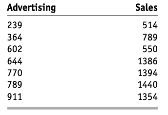

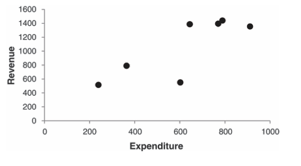

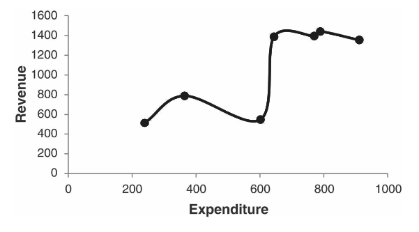

## Creation and Use of Data Partitions

- Using the same data for both fitting a model and evaluating it leads to **optimism bias**
  - Where chance aspects of the data favor one model.
- The solution is to **partition**
  - the data into separate sets and train on one while validating on the other.

**Note**

In a classification model, for instance, we might measure the misclassification rate on the held-back (validation) set. A model that does well on new data is said to **generalize** well.

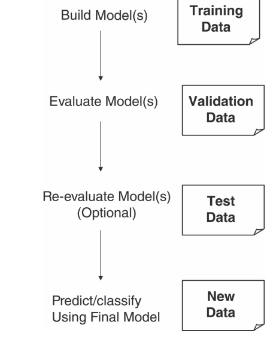

## Data Partitioning

- **Training Partition**
  - The **training partition** (usually the largest portion) is used to build the various candidate models.
- **Validation Partition**
  - The **validation partition** (sometimes called the test partition) is used to assess each model’s performance and pick the best one.
  - In some algorithms (e.g., classification and regression trees), the validation set may also be used repeatedly in building or tuning the model.
- **Test Partition**
  - A separate **test partition** (holdout or evaluation partition) can be used for a final unbiased estimate of the chosen model’s performance.
  - After a model is chosen from among several, some “chance” aspects of the validation data may have favored that model
  - So measuring final performance on a new, untouched test partition provides a more realistic estimate.

```r
#### Table 2.9

# use set.seed() to get the same partitions when re-running the R code.
set.seed(1)

## partitioning into training (60%) and validation (40%)
# randomly sample 60% of the row IDs for training; the remaining 40% serve as
# validation
train.rows <- sample(rownames(housing.df), dim(housing.df)[1]*0.6)
# collect all the columns with training row ID into training set:
train.data <- housing.df[train.rows, ]
# assign row IDs that are not already in the training set, into validation
valid.rows <- setdiff(rownames(housing.df), train.rows)
valid.data <- housing.df[valid.rows, ]

# alternative code for validation (works only when row names are numeric):
# collect all the columns without training row ID into validation set
#valid.data <- housing.df[-train.rows, ] # does not work in this case

## partitioning into training (50%), validation (30%), test (20%)
# randomly sample 50% of the row IDs for training
train.rows <- sample(rownames(housing.df), dim(housing.df)[1]*0.5)

# sample 30% of the row IDs into the validation set, drawing only from records
# not already in the training set
# use setdiff() to find records not already in the training set
valid.rows <- sample(setdiff(rownames(housing.df), train.rows),
                     dim(housing.df)[1]*0.3)

# assign the remaining 20% row IDs serve as test
test.rows <- setdiff(rownames(housing.df), union(train.rows, valid.rows))

# create the 3 data frames by collecting all columns from the appropriate rows
train.data <- housing.df[train.rows, ]
valid.data <- housing.df[valid.rows, ]
test.data <- housing.df[test.rows, ]
```

### Cross-Validation

- When the dataset is small, partitioning may not be advisable because each partition will be too small.
- **Cross-validation** helps in this scenario.
  - One popular method is **k-fold cross-validation**, where the data are randomly split into k non-overlapping folds (e.g., k=5, each fold is 20% of the data).
  - The model is trained k times, each time using k−1 folds as the training set and the remaining fold as the validation set.
  - This means every record ends up in a validation partition once.
  - Predictions from each fold can be aggregated for an overall performance measure.

# Building a Predictive Model

Let us go through the steps typical of many data mining tasks using multiple linear regression as an example. This illustrates the overall process before we tackle other algorithms.

## Modeling Process

1. **Determine the Purpose**
2. **Obtain the Data**
3. **Explore, Clean, and Preprocess the Data**
4. **Reduce the Data Dimension**
5. **Determine the Data Mining Task**
6. **Partition the Data**
7. **Choose the Technique**
8. **Use the Algorithm to Perform the Task**
9. **Interpret the Results**
10. **Deploy the Model**
1. **Determine the Purpose**
- We want to predict the value of homes in West Roxbury for new records.
2. **Obtain the Data**
- We use the 2014 West Roxbury housing data. The dataset is small enough not to require further sampling.
3. **Explore, Clean, and Preprocess the Data**
   - Check the **data dictionary** (variable descriptions) to ensure clarity about each variable.
   - Consider **TAX**: because tax is a function of assessed value, it might not be useful if assessed value is not known.
   - Look for **outliers**. Example: a record showing 15 floors is likely an error (maybe 1.5).
   - Create **dummy variables** for categorical variables. In our example, **REMODEL** has three categories.
4. **Reduce the Data Dimension**
- The West Roxbury dataset already has a small number of variables.
- In larger datasets, you might condense or transform multiple variables or combine categories if appropriate.
5. **Determine the Data Mining Task**
- Our task is a **supervised prediction** of **TOTAL VALUE** using the predictor variables (excluding TAX).
6. **Partition the Data**
- We divide the data into training and validation sets as per Table 2.9.
- The model is built on the training set, then tested on the validation set to see how it performs on new data. (A test partition can also be used, but we omit it for simplicity here.)
7. **Choose the Technique**
- Here, we use **multiple linear regression**.
- After training the model on the training set, we apply it to the validation set.
8. **Use the Algorithm to Perform the Task**
- In R, we use `lm()` on the training data to predict house value, then apply the fitted model to the validation data.
- Table 2.11 shows predicted (fitted) values and residuals for training, and Table 2.12 for validation.
- Table 2.13 compares errors (e.g., mean error, root-mean-squared error, etc.).
- As expected, error is smaller on the training data than on the validation data.

```
Table2.11,12
```

```r
reg <- lm(TOTAL_VALUE ~ .-TAX, data = housing.df, subset = train.rows) # remove variable "TAX"
tr.res <- data.frame(train.data$TOTAL_VALUE, reg$fitted.values, reg$residuals)
head(tr.res)
```

```
     train.data.TOTAL_VALUE reg.fitted.values reg.residuals
1886                  356.7          351.8696      4.830387
3515                  333.3          319.6167     13.683309
460                   298.6          359.6946    -61.094591
855                   265.3          327.2212    -61.921179
4094                  575.1          527.5254     47.574602
3581                  348.0          379.0349    -31.034906
```

```r
pred <- predict(reg, newdata = valid.data)
vl.res <- data.frame(valid.data$TOTAL_VALUE, pred, residuals =
                       valid.data$TOTAL_VALUE - pred)
head(vl.res)
```

```
     valid.data.TOTAL_VALUE     pred  residuals
5642                  318.0 370.0624 -52.062424
2766                  498.7 430.2489  68.451080
3676                  331.8 352.5804 -20.780417
2054                  371.9 374.6068  -2.706755
2217                  436.2 437.6979  -1.497862
3117                  280.2 255.3652  24.834815
```

```
Table2.13 Forecasting
```

```r
library(forecast)
# compute accuracy on training set
accuracy(reg$fitted.values, train.data$TOTAL_VALUE)
```

```
                    ME     RMSE    MAE       MPE     MAPE
Test set -1.175665e-15 41.99487 31.857 -1.065399 8.352223
```

```r
# compute accuracy on prediction set
pred <- predict(reg, newdata = valid.data)
accuracy(pred, valid.data$TOTAL_VALUE)
```

```
                ME     RMSE      MAE        MPE    MAPE
Test set 0.4009506 43.13094 32.65558 -0.8548947 8.41257
```

# Using R for Data Mining on a Local Machine

- A key point is that heavy-duty data mining often does not require the complete dataset of millions of records.
- As with polling, a sufficiently large **sample** (e.g., 20,000 records) can yield an accurate model.
- Therefore, each partition (training, validation, test) can typically be handled in R’s available memory.
- For very large datasets (“Big Data”), you might need to manage memory, removing unused objects (rm()) and calling garbage collection (gc()). Various packages in R also support parallel and large-scale computations.

# Automating Data Mining Solutions

- Most supervised data mining applications aim for an **ongoing** predictive or classification process, not a one-time analysis.
- During **prototype mode**, you explore different algorithms and fine-tune them.
- Once the final model is chosen, it is typically **deployed** in an automated workflow or **data pipeline**.

**For instance**

- The IRS processes hundreds of millions of tax returns and applies a fraud model automatically during normal processing.
- Music streaming services (e.g., Pandora, Spotify) instantly generate personalized recommendations using embedded models.
- These systems require the predictive algorithm to be built into the **computational setting** via **APIs**
  - API is that define how data flow in and out.
  - After deployment, models must be monitored and periodically **re-evaluated** because
    - conditions change over time (e.g., consumer behavior, economic factors)
    - predictive performance can degrade.
  - Models often have short shelf lives—sometimes only a year.
  - When performance declines, we return to prototype mode and create a fresh model.

> Although our focus here is on the **prototyping phase**—defining, developing, and selecting models—be aware that the real effort in practice often lies in automated deployment and its maintenance.

# House management

## More to Read

- Data Mining: Concepts and Techniques (3rd Edition). Han, J., Kamber, M., & Pei, J. (2011). Morgan Kaufmann Publishers.
  - This comprehensive textbook provides a structured introduction to data mining procedures, covering methods like anomaly detection, clustering, association rule mining, and predictive analytics applied extensively in the business environment.
- Discovering Knowledge in Data: An Introduction to Data Mining (2nd Edition). Larose, D.T. & Larose, C.D. (2014). John Wiley & Sons.
  - This book clearly introduces systematic data mining process stages, highlighting examples of developing predictive analytics models and supporting strategic business decision-making.
- Beyond the hype: The hard work behind analytics success. Ransbotham, S., Kiron, D., & Prentice, P. K. (2016). MIT Sloan Management Review, 57(3), 1-17.
  - This research article discusses the practical implementation of data mining processes within organizations. It outlines how enterprises systematically adopt advanced analytics and data mining approaches to drive business performance.
- Data Science for Business: What You Need to Know about Data Mining and Data-Analytic Thinking. Provost, F., & Fawcett, T. (2013). O’Reilly Media.
  - This text introduces frameworks and step-by-step procedures demonstrating how data mining can solve real-world business analytics problems, emphasizing strategic thinking and practical business application.
- A Data Mining & Knowledge Discovery Process Model. Marban, O., Mariscal, G., & Segovia, J. (2009).
  - In Data Mining and Knowledge Discovery in Real Life Applications, InTech, pp. 1-18. This research provides a clear methodological introduction of a well-defined data mining and knowledge discovery process model particularly designed for effective application in business analytics scenarios.

## Assignment

- What to do
- Requirement
  - PDF format
  - file name should be include your student id and name
    - stuID_name_title.pdf (e.g. 1111111_ChungilChae_SelfIntroduction.pdf)
- Due date
  - by DATE 11:59PM
  - NO LATE SUBMISSION ALLOWED!!!!

# Reference

Shmueli, G., Bruce, P. C., Yahav, I., Patel, N. R., & Lichtendahl Jr, K. C. (2017). *Data mining for business analytics: Concepts, techniques, and applications in r*. John Wiley & Sons.